# 2026 SISBID High-Dimensional Hypothesis Testing Demo

Genevera I. Allen and Yufeng Liu

## Load packages

```r
required_pkgs <- c("sda", "ggplot2")
missing_pkgs <- required_pkgs[!vapply(required_pkgs, requireNamespace, logical(1), quietly = TRUE)]

if (length(missing_pkgs) > 0) {
  stop(
    "Please install the following packages before knitting this demo: ",
    paste(missing_pkgs, collapse = ", ")
  )
}

library(sda)
library(ggplot2)

theme_set(theme_minimal(base_size = 13))
```

We will consider many feature-wise tests of the form

$$H_0: \text{feature is not associated with the response}.$$

The main goal of this demo is to show why unadjusted p-values can be misleading when many hypotheses are tested, and how procedures such as Bonferroni and Benjamini–Hochberg behave in simple examples.

## Helper functions

```r
feature_t_tests <- function(x, y) {
  # x should be features x samples.
  # y should contain two class labels, one per sample.
  y <- factor(y)
  stopifnot(ncol(x) == length(y), nlevels(y) == 2)

  apply(x, 1, function(z) t.test(z ~ y)$p.value)
}

bh_rejection_count <- function(p_values, alpha = 0.1) {
  p_ordered <- sort(p_values)
  m <- length(p_ordered)
  hits <- which(p_ordered <= alpha * seq_len(m) / m)
  if (length(hits) == 0) 0 else max(hits)
}

bonferroni_rejection_count <- function(p_values, alpha = 0.1) {
  sum(p_values <= alpha / length(p_values))
}

plot_adjusted_vs_raw <- function(p_values, title) {
  plot_df <- data.frame(
    OriginalP = p_values,
    BHAdjustedP = p.adjust(p_values, method = "BH")
  )

  ggplot(plot_df, aes(x = OriginalP, y = BHAdjustedP)) +
    geom_point(alpha = 0.55) +
    geom_abline(intercept = 0, slope = 1, linetype = "dashed") +
    coord_equal(xlim = c(0, 1), ylim = c(0, 1)) +
    labs(
      title = title,
      x = "Original p-values",
      y = "BH-adjusted p-values"
    )
}

plot_ordered_p <- function(p_values, alpha = 0.1, n_show = 100, title = NULL) {
  p_ordered <- sort(p_values)
  m <- length(p_ordered)
  n_show <- min(n_show, m)

  plot_df <- data.frame(
    Index = seq_len(n_show),
    OrderedP = p_ordered[seq_len(n_show)],
    BHBoundary = alpha * seq_len(n_show) / m,
    BonferroniBoundary = alpha / m
  )

  ggplot(plot_df, aes(x = Index, y = OrderedP)) +
    geom_point(size = 1.8, alpha = 0.75) +
    geom_line(aes(y = BHBoundary), linewidth = 0.8) +
    geom_hline(yintercept = alpha / m, linetype = "dashed") +
    labs(
      title = title,
      subtitle = paste0(
        "BH line and Bonferroni threshold shown at alpha = ", alpha
      ),
      x = "Index of ordered p-value",
      y = "Ordered p-value"
    )
}

plot_bh_adjusted_by_index <- function(p_values, title) {
  plot_df <- data.frame(
    Index = seq_along(p_values),
    BHAdjustedP = p.adjust(p_values, method = "BH")
  )

  ggplot(plot_df, aes(x = Index, y = BHAdjustedP)) +
    geom_point(alpha = 0.55) +
    labs(
      title = title,
      x = "Feature index",
      y = "BH-adjusted p-value"
    )
}
```

## Data set 1: simulated data, all null hypotheses true

In this first example, none of the features are truly associated with the binary response. Even so, when we run 1000 tests, we should expect some small p-values by chance.

```r
n_features <- 1000
n_samples <- 50

x <- matrix(rnorm(n_features * n_samples), nrow = n_features, ncol = n_samples)
y <- sample(c(0, 1), n_samples, replace = TRUE)

p_values_null <- feature_t_tests(x, y)

cat(
  "Proportion of unadjusted p-values below 0.05:",
  round(mean(p_values_null < 0.05), 3),
  "\n"
)
```

```
## Proportion of unadjusted p-values below 0.05: 0.044
```

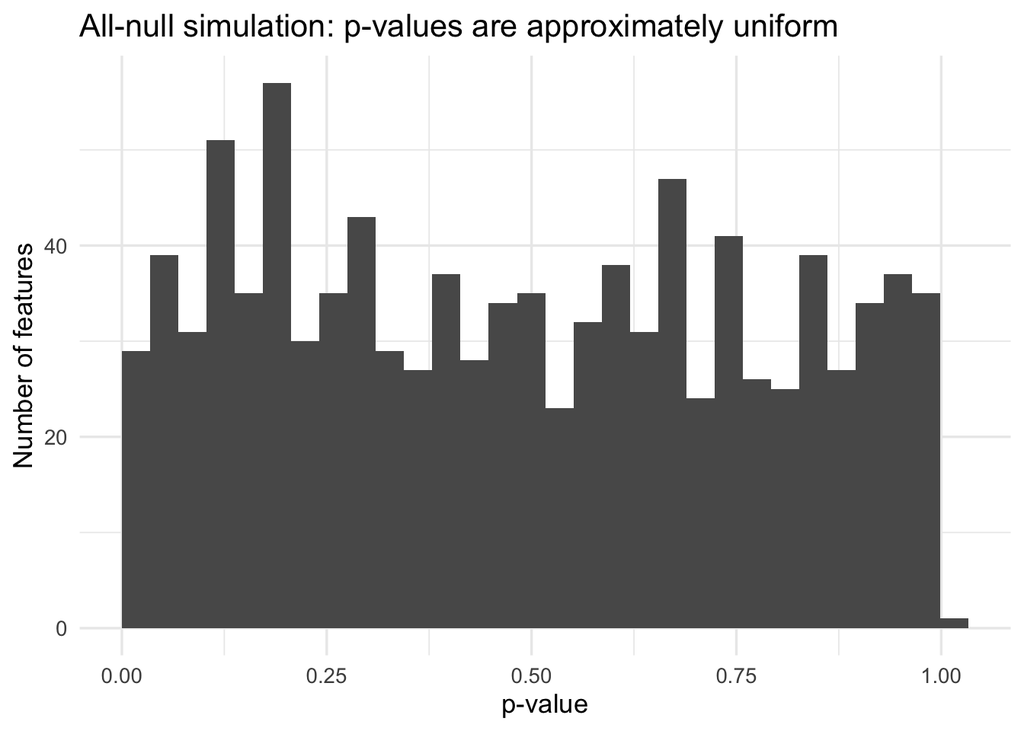

```r
ggplot(data.frame(PValue = p_values_null), aes(x = PValue)) +
  geom_histogram(boundary = 0, bins = 30) +
  labs(
    title = "All-null simulation: p-values are approximately uniform",
    x = "p-value",
    y = "Number of features"
  )
```

### Benjamini–Hochberg adjustment

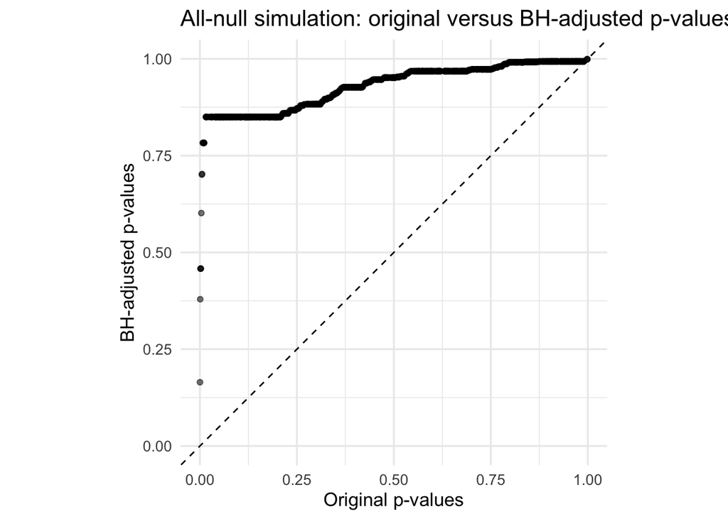

```r
plot_adjusted_vs_raw(
  p_values_null,
  title = "All-null simulation: original versus BH-adjusted p-values"
)
```

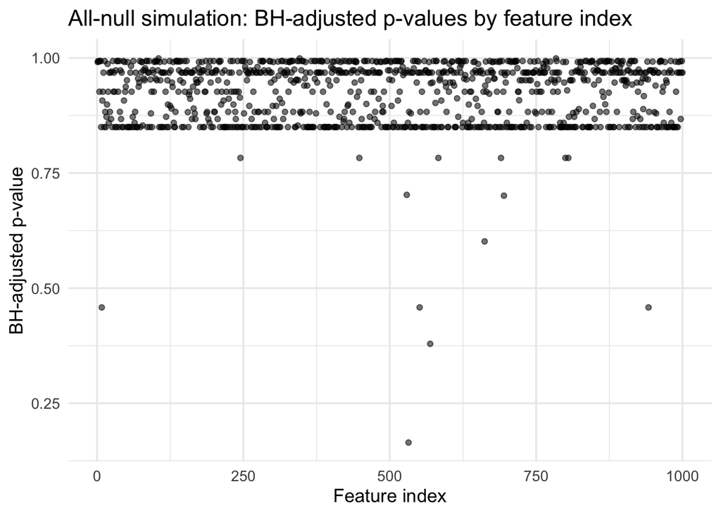

```r
plot_bh_adjusted_by_index(
  p_values_null,
  title = "All-null simulation: BH-adjusted p-values by feature index"
)
```

## Data set 2: simulated data, some alternatives true

In this second example, the first 100 features have a shifted mean in one group. Now not all null hypotheses are true, and we should see many more small p-values.

```r
x <- matrix(rnorm(n_features * n_samples), nrow = n_features, ncol = n_samples)
y <- sample(c(0, 1), n_samples, replace = TRUE)

signal_features <- 1:100
x[signal_features, y == 0] <- x[signal_features, y == 0] + 1

p_values_signal <- feature_t_tests(x, y)

cat(
  "Proportion of unadjusted p-values below 0.05:",
  round(mean(p_values_signal < 0.05), 3),
  "\n"
)
```

```
## Proportion of unadjusted p-values below 0.05: 0.142
```

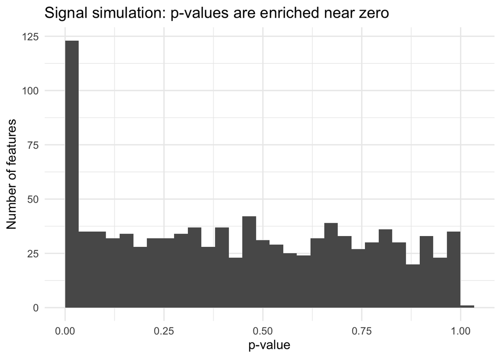

```r
ggplot(data.frame(PValue = p_values_signal), aes(x = PValue)) +
  geom_histogram(boundary = 0, bins = 30) +
  labs(
    title = "Signal simulation: p-values are enriched near zero",
    x = "p-value",
    y = "Number of features"
  )
```

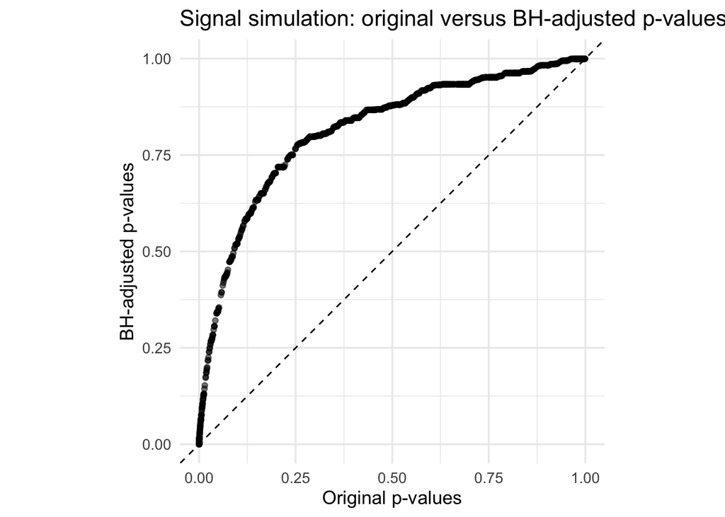

```r
plot_adjusted_vs_raw(
  p_values_signal,
  title = "Signal simulation: original versus BH-adjusted p-values"
)
```

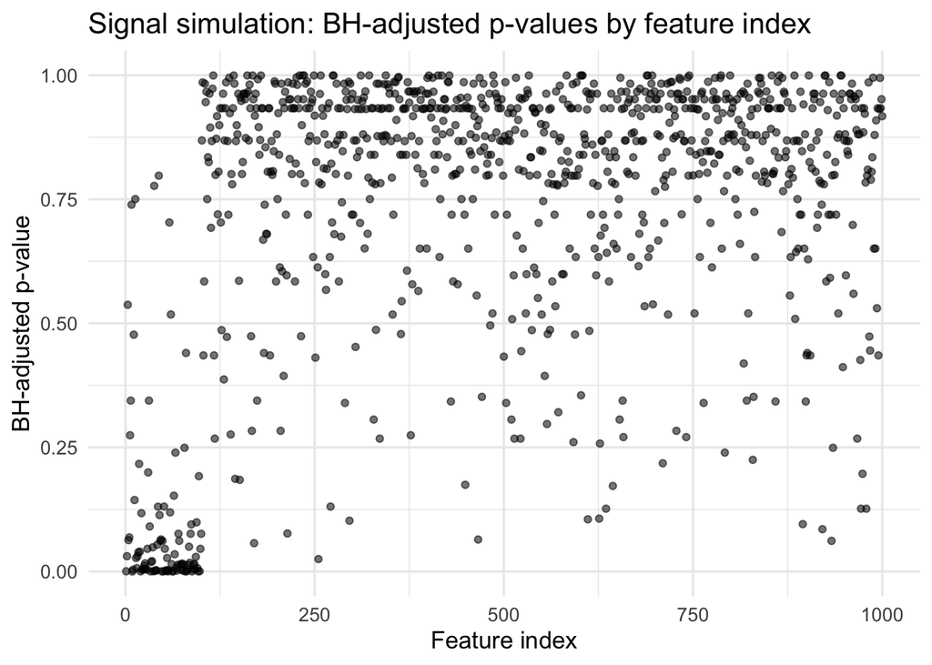

```r
plot_bh_adjusted_by_index(
  p_values_signal,
  title = "Signal simulation: BH-adjusted p-values by feature index"
)
```

### Directly visualizing the BH rule

The BH procedure rejects all hypotheses up to the largest ordered p-value below the line

$$p_{(i)} \leq \alpha \frac{i}{m}.$$

Bonferroni rejects p-values below the horizontal threshold $\alpha / m$.

```r
alpha <- 0.4

fdrs_bh_signal <- p.adjust(p_values_signal, method = "BH")

cat(
  "Number of tests with BH-adjusted p-value below", alpha, ":",
  sum(fdrs_bh_signal < alpha),
  "\n"
)
```

```
## Number of tests with BH-adjusted p-value below 0.4 : 148
```

```r
cat(
  "Number of BH rejections computed directly:",
  bh_rejection_count(p_values_signal, alpha = alpha),
  "\n"
)
```

```
## Number of BH rejections computed directly: 148
```

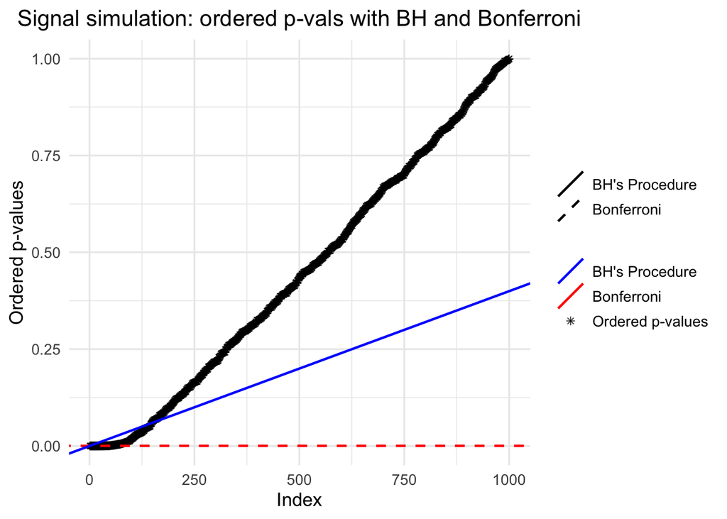

```r
# This follows the original demo plot: order the raw p-values, then
# overlay the Bonferroni horizontal threshold and the BH step-up boundary.
BHData <- data.frame(
  OriginalP = p_values_signal,
  BH.P = fdrs_bh_signal
)
BHData <- BHData[order(BHData$OriginalP, decreasing = FALSE), ]
BHData$index <- seq_len(nrow(BHData))

boundary_df <- data.frame(
  Method = c("Bonferroni", "BH's Procedure"),
  intercept = c(alpha / nrow(BHData), 0),
  slope = c(0, alpha / nrow(BHData))
)

ggplot(BHData, aes(x = index, y = OriginalP)) +
  geom_point(aes(color = "Ordered p-values"), shape = 8, alpha = 0.75) +
  geom_abline(
    data = boundary_df,
    aes(intercept = intercept, slope = slope, color = Method, linetype = Method),
    linewidth = 0.8
  ) +
  scale_color_manual(
    name = NULL,
    values = c(
      "Bonferroni" = "red",
      "BH's Procedure" = "blue",
      "Ordered p-values" = "black"
    ),
    breaks = c("BH's Procedure", "Bonferroni", "Ordered p-values")
  ) +
  scale_linetype_manual(
    name = NULL,
    values = c("Bonferroni" = "dashed", "BH's Procedure" = "solid"),
    breaks = c("BH's Procedure", "Bonferroni")
  ) +
  labs(
    title = "Signal simulation: ordered p-vals with BH and Bonferroni",
    x = "Index",
    y = "Ordered p-values"
  ) +
  theme(plot.title = element_text(hjust = 0.5))
```

## Data set 3: real data, prostate cancer expression data

The prostate cancer data set from Singh et al. (2002) contains gene expression measurements for 6033 genes across 102 men. The data set is available from the R package `sda`.

In this example, we test each gene for differential expression between healthy and cancer samples.

```r
data(singh2002)

x <- singh2002$x
y <- factor(singh2002$y)

n_healthy <- sum(y == "healthy")
n_cancer <- length(y) - n_healthy

cat("Number of healthy samples:", n_healthy, "\n")
```

```
## Number of healthy samples: 50
```

```r
cat("Number of cancer samples:", n_cancer, "\n")
```

```
## Number of cancer samples: 52
```

```r
cat("Number of genes:", ncol(x), "\n")
```

```
## Number of genes: 6033
```

```r
# x is samples x genes for the prostate data.
# Use the labels directly rather than assuming the samples are ordered by class.
p_values_prostate <- apply(x, 2, function(z) t.test(z ~ y)$p.value)

if (is.null(colnames(x))) {
  gene_id <- paste0("Gene_", seq_len(ncol(x)))
} else {
  gene_id <- colnames(x)
}

prostate_results <- data.frame(
  Gene = gene_id,
  PValue = p_values_prostate,
  BHAdjustedP = p.adjust(p_values_prostate, method = "BH"),
  BonferroniAdjustedP = p.adjust(p_values_prostate, method = "bonferroni")
)

prostate_results <- prostate_results[order(prostate_results$PValue), ]

knitr::kable(
  head(prostate_results, 10),
  digits = 4,
  caption = "Top genes ranked by raw p-value"
)
```

Top genes ranked by raw p-value

|  | Gene | PValue | BHAdjustedP | BonferroniAdjustedP |
| --- | --- | --- | --- | --- |
| 610 | Gene_610 | 0 | 0.0011 | 0.0011 |
| 1720 | Gene_1720 | 0 | 0.0048 | 0.0095 |
| 364 | Gene_364 | 0 | 0.0151 | 0.0594 |
| 914 | Gene_914 | 0 | 0.0151 | 0.0699 |
| 332 | Gene_332 | 0 | 0.0151 | 0.0858 |
| 3940 | Gene_3940 | 0 | 0.0151 | 0.0906 |
| 4546 | Gene_4546 | 0 | 0.0183 | 0.1282 |
| 1068 | Gene_1068 | 0 | 0.0188 | 0.1732 |
| 579 | Gene_579 | 0 | 0.0188 | 0.1978 |
| 4331 | Gene_4331 | 0 | 0.0188 | 0.2053 |

```r
alpha <- 0.1
m_prostate <- length(p_values_prostate)
p1 <- sort(p_values_prostate)

cat(
  "Number of Bonferroni rejections at alpha =", alpha, ":",
  bonferroni_rejection_count(p_values_prostate, alpha = alpha),
  "\n"
)
```

```
## Number of Bonferroni rejections at alpha = 0.1 : 6
```

```r
cat(
  "Number of BH rejections at FDR level", alpha, ":",
  bh_rejection_count(p_values_prostate, alpha = alpha),
  "\n"
)
```

```
## Number of BH rejections at FDR level 0.1 : 57
```

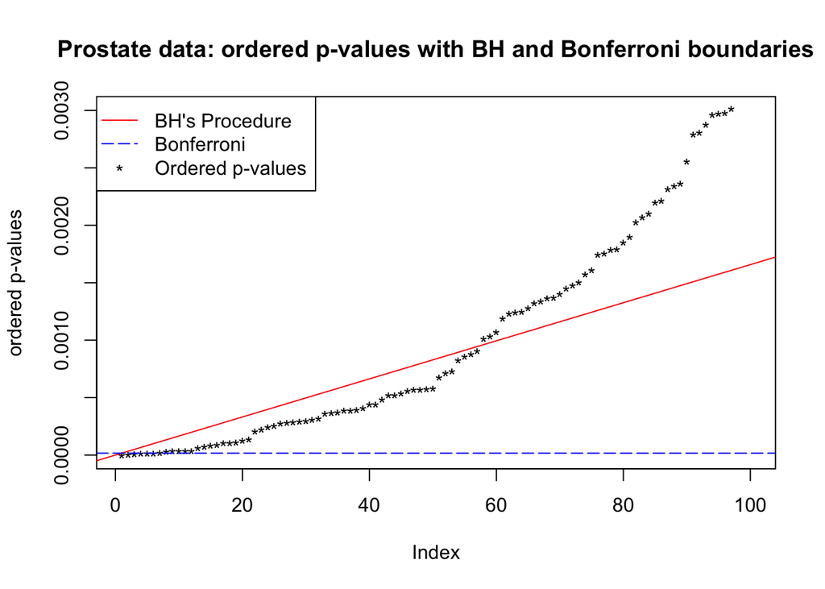

```r
# This keeps the original base-R plot style and adds the legend explicitly.
plot(
  p1[1:100],
  pch = rep("*", 100),
  ylim = c(0, 0.003),
  xlab = "Index",
  ylab = "ordered p-values",
  main = "Prostate data: ordered p-values with BH and Bonferroni boundaries"
)

# Rejection boundary of Benjamini-Hochberg's procedure.
abline(a = 0, b = alpha / m_prostate, col = "red")

# Rejection boundary of Bonferroni at alpha.
abline(a = alpha / m_prostate, b = 0, col = "blue", lty = 5)

legend(
  "topleft",
  legend = c("BH's Procedure", "Bonferroni", "Ordered p-values"),
  lty = c(1, 5, NA),
  col = c("red", "blue", "black"),
  pch = c(NA, NA, "*")
)
```

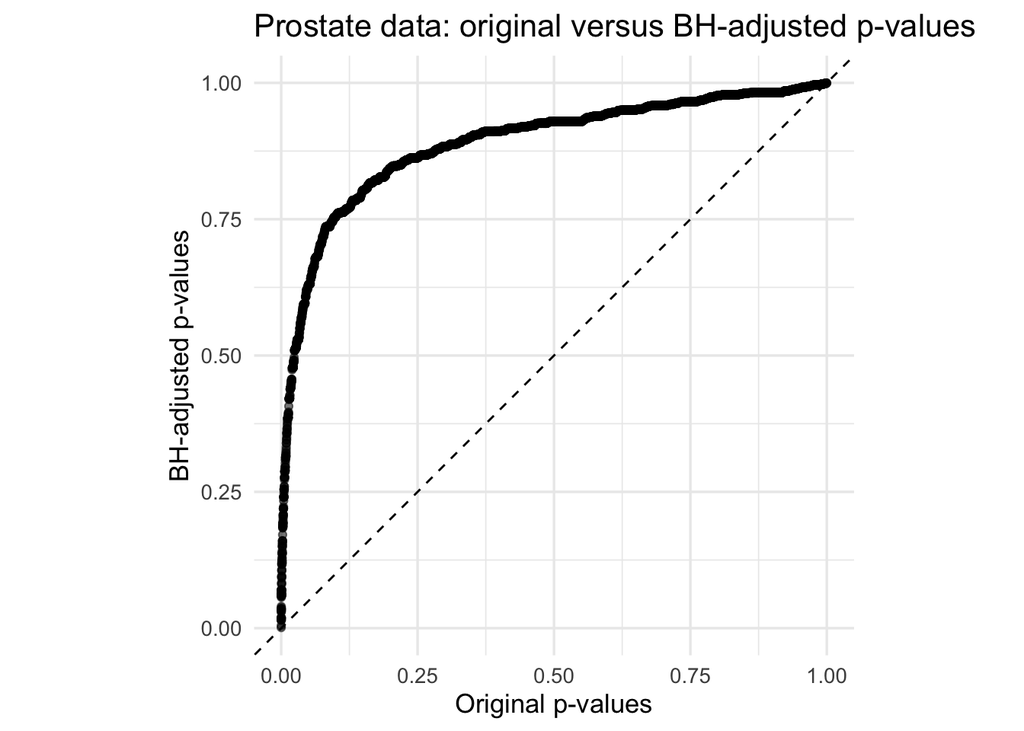

```r
plot_adjusted_vs_raw(
  p_values_prostate,
  title = "Prostate data: original versus BH-adjusted p-values"
)
```